# Point-by-point response analyses: mutation position and sequencing-quality checks

Francesco Gazzo

2026-05-06

# 1 Aim of the analysis

This report documents the additional analyses performed for the point-by-point response.

The goal is to show, in a reproducible way, how the figures and statistical summaries were generated.

The report focuses on two main questions:

1. Are mutations spatially enriched around the integration site?
2. Do ALT-supporting bases show evidence of technical bias, such as proximity to read ends or reduced Phred quality?

# 2 Setup

```r
knitr::opts_chunk$set(
  echo = TRUE,
  message = FALSE,
  warning = FALSE,
  fig.width = 8,
  fig.height = 5,
  dpi = 300
)

suppressPackageStartupMessages({
  library(openxlsx)
  library(dplyr)
  library(stringr)
  library(tidyr)
  library(purrr)
  library(broom)
  library(ggplot2)
  library(knitr)
})

# ----------------------------------------------------------
# Load custom ggplot theme, if available
# ----------------------------------------------------------

if (file.exists(params$theme_file)) {
  source(params$theme_file)
} else {
  message("ggplot.R not found. Using theme_bw() as fallback.")
  my_theme <- theme_bw(base_size = 12)
}

# ----------------------------------------------------------
# Output folders
# ----------------------------------------------------------

output_dir <- "point_by_point_outputs"
plot_dir <- file.path(output_dir, "plots")
table_dir <- file.path(output_dir, "tables")

dir.create(output_dir, showWarnings = FALSE)
dir.create(plot_dir, showWarnings = FALSE)
dir.create(table_dir, showWarnings = FALSE)

# ----------------------------------------------------------
# Dataset order and colors
# ----------------------------------------------------------

dataset_levels <- c(
  "Cdkn2a-/- LV.SF.LTR",
  "Cdkn2a-/- SIN.LV.PGK",
  "WT LV.SF.LTR",
  "WT SIN.LV.PGK"
)

dataset_colors <- c(
  "Cdkn2a-/- LV.SF.LTR" = "#7fb3d5",
  "Cdkn2a-/- SIN.LV.PGK" = "#FF8C00",
  "WT LV.SF.LTR" = "#8FBC8B",
  "WT SIN.LV.PGK" = "#D98880"
)
```

# 3 Input files

This report uses two input files:

```r
input_files <- c(
  params$mpileup_summary_file,
  params$phred_wide_file
)

input_files
```

```
## [1] "mpileup_quality_summary_per_mutation.xlsx"
## [2] "df_phred_wide.xlsx"
```

```r
missing_files <- input_files[!file.exists(input_files)]

if (length(missing_files) > 0) {
  stop(
    "Missing input file(s): ",
    paste(missing_files, collapse = ", "),
    ". Please place them in the working directory or update the YAML params."
  )
}
```

# 4 Load data

```r
df_raw <- read.xlsx(params$mpileup_summary_file)
df_phred <- read.xlsx(params$phred_wide_file)

data.frame(
  dataset = c("mpileup summary", "phred wide"),
  rows = c(nrow(df_raw), nrow(df_phred)),
  columns = c(ncol(df_raw), ncol(df_phred))
) %>%
  kable(caption = "Input dataset dimensions")
```

Input dataset dimensions

| dataset | rows | columns |
| --- | --- | --- |
| mpileup summary | 1670 | 8 |
| phred wide | 1639 | 12 |

# 5 Required columns

```r
required_raw_cols <- c(
  "ID_gene",
  "locus",
  "GenVec",
  "Mutation"
)

required_phred_cols <- c(
  "delta_ALT_minus_REF_dist_to_end",
  "delta_ALT_minus_REF_phred"
)

missing_raw_cols <- setdiff(required_raw_cols, names(df_raw))
missing_phred_cols <- setdiff(required_phred_cols, names(df_phred))

if (length(missing_raw_cols) > 0) {
  stop(
    "Missing column(s) in ",
    params$mpileup_summary_file,
    ": ",
    paste(missing_raw_cols, collapse = ", ")
  )
}

if (length(missing_phred_cols) > 0) {
  stop(
    "Missing column(s) in ",
    params$phred_wide_file,
    ": ",
    paste(missing_phred_cols, collapse = ", ")
  )
}
```

# 6 1. Spatial distribution of mutations relative to the integration site

## 6.1 Rationale

This analysis evaluates where mutations are located relative to the integration site.

The integration-site coordinate is extracted from `ID_gene`.

The signed distance is calculated as:

Definition of signed distance from integration site

| variable | definition |
| --- | --- |
| distance_from_is | locus - is_position |

Interpretation:

- negative values indicate mutations upstream of the integration site;
- positive values indicate mutations downstream of the integration site;
- values close to zero indicate mutations close to the integration site.

## 6.2 Build mutation-to-IS distance table

```r
df_distance <- df_raw %>%
  mutate(
    is_position = as.numeric(
      str_match(ID_gene, "chr[0-9A-Za-z]+_([0-9]+)_")[, 2]
    ),
    distance_from_is = locus - is_position,
    abs_distance_from_is = abs(distance_from_is),
    GenVec = factor(GenVec, levels = dataset_levels)
  ) %>%
  filter(
    !is.na(GenVec),
    !is.na(is_position),
    !is.na(locus),
    !is.na(distance_from_is)
  ) %>%
  separate(
    GenVec,
    into = c("Genotype", "Vector"),
    sep = " ",
    remove = FALSE,
    extra = "merge"
  ) %>%
  select(
    GenVec,
    Genotype,
    Vector,
    Mutation,
    ID_gene,
    is_position,
    locus,
    distance_from_is,
    abs_distance_from_is
  )

if (nrow(df_distance) == 0) {
  stop("No valid rows available after building df_distance.")
}

head(df_distance, 10) %>%
  kable(caption = "First rows of the mutation-to-IS distance table")
```

First rows of the mutation-to-IS distance table

| GenVec | Genotype | Vector | Mutation | ID_gene | is_position | locus | distance_from_is | abs_distance_from_is |
| --- | --- | --- | --- | --- | --- | --- | --- | --- |
| Cdkn2a-/- SIN.LV.PGK | Cdkn2a-/- | SIN.LV.PGK | chr2_174956804_A_G | 0610010B08Rik_-__chr2_174956774_+_ | 174956774 | 174956804 | 30 | 30 |
| Cdkn2a-/- LV.SF.LTR | Cdkn2a-/- | LV.SF.LTR | chr12_56432798_C_A | 1110008L16Rik_+__chr12_56433155_-_ | 56433155 | 56432798 | -357 | 357 |
| WT SIN.LV.PGK | WT | SIN.LV.PGK | chr6_13864350_T_C | 1110019D14Rik_+__chr6_13864383_-_ | 13864383 | 13864350 | -33 | 33 |
| Cdkn2a-/- LV.SF.LTR | Cdkn2a-/- | LV.SF.LTR | chr2_91262421_T_C | 1110051M20Rik_-__chr2_91262601_-_ | 91262601 | 91262421 | -180 | 180 |
| WT LV.SF.LTR | WT | LV.SF.LTR | chr18_17268050_C_G | 1700001G01Rik_+__chr18_17267877_+_ | 17267877 | 17268050 | 173 | 173 |
| WT LV.SF.LTR | WT | LV.SF.LTR | chr18_17268052_G_C | 1700001G01Rik_+__chr18_17267877_+_ | 17267877 | 17268052 | 175 | 175 |
| Cdkn2a-/- LV.SF.LTR | Cdkn2a-/- | LV.SF.LTR | chr13_119273935_T_C | 1700003P14Rik_+__chr13_119273953_-_ | 119273953 | 119273935 | -18 | 18 |
| Cdkn2a-/- SIN.LV.PGK | Cdkn2a-/- | SIN.LV.PGK | chr3_124175949_T_C | 1700006A11Rik_-__chr3_124175816_+_ | 124175816 | 124175949 | 133 | 133 |
| WT SIN.LV.PGK | WT | SIN.LV.PGK | chr17_9208164_T_C | 1700010I14Rik_+__chr17_9208023_+_ | 9208023 | 9208164 | 141 | 141 |
| WT SIN.LV.PGK | WT | SIN.LV.PGK | chr13_5296925_A_T | 1700016G22Rik_-__chr13_5297151_-_ | 5297151 | 5296925 | -226 | 226 |

## 6.3 Descriptive summary

```r
distance_summary <- df_distance %>%
  group_by(GenVec, Genotype, Vector) %>%
  summarise(
    n_mutations = n(),
    mean_distance_from_is = mean(distance_from_is, na.rm = TRUE),
    median_distance_from_is = median(distance_from_is, na.rm = TRUE),
    sd_distance_from_is = sd(distance_from_is, na.rm = TRUE),
    median_abs_distance_from_is = median(abs_distance_from_is, na.rm = TRUE),
    iqr_abs_distance_from_is = IQR(abs_distance_from_is, na.rm = TRUE),
    min_distance_from_is = min(distance_from_is, na.rm = TRUE),
    max_distance_from_is = max(distance_from_is, na.rm = TRUE),
    pct_within_100_bp = mean(abs_distance_from_is <= 100, na.rm = TRUE) * 100,
    pct_within_1kb = mean(abs_distance_from_is <= 1000, na.rm = TRUE) * 100,
    .groups = "drop"
  )

write.csv(
  distance_summary,
  file.path(table_dir, "distance_from_is_summary.csv"),
  row.names = FALSE
)

distance_summary %>%
  kable(
    digits = 3,
    caption = "Summary of mutation distances from integration site"
  )
```

Summary of mutation distances from integration site

| GenVec | Genotype | Vector | n_mutations | mean_distance_from_is | median_distance_from_is | sd_distance_from_is | median_abs_distance_from_is | iqr_abs_distance_from_is | min_distance_from_is | max_distance_from_is | pct_within_100_bp | pct_within_1kb |
| --- | --- | --- | --- | --- | --- | --- | --- | --- | --- | --- | --- | --- |
| Cdkn2a-/- LV.SF.LTR | Cdkn2a-/- | LV.SF.LTR | 264 | 4.220 | 14.5 | 165.216 | 71 | 146.25 | -520 | 598 | 62.121 | 100 |
| Cdkn2a-/- SIN.LV.PGK | Cdkn2a-/- | SIN.LV.PGK | 549 | -2.916 | -7.0 | 186.369 | 89 | 177.00 | -714 | 524 | 54.098 | 100 |
| WT LV.SF.LTR | WT | LV.SF.LTR | 303 | -6.020 | -1.0 | 225.434 | 99 | 201.00 | -688 | 599 | 50.165 | 100 |
| WT SIN.LV.PGK | WT | SIN.LV.PGK | 554 | 6.668 | 8.0 | 206.317 | 110 | 205.00 | -539 | 610 | 47.834 | 100 |

## 6.4 Statistical test: is signed distance centered around zero?

For each dataset, a one-sample Wilcoxon signed-rank test is used to evaluate whether the signed distance distribution is centered around zero.

```r
safe_wilcox_test <- function(x) {
  x <- x[!is.na(x)]

  if (length(x) < 3 || length(unique(x)) < 2) {
    return(tibble(
      statistic = NA_real_,
      p.value = NA_real_,
      method = "Wilcoxon signed-rank test",
      alternative = "two.sided",
      note = "Insufficient sample size or variability"
    ))
  }

  broom::tidy(
    wilcox.test(x, mu = 0, exact = FALSE)
  ) %>%
    mutate(note = NA_character_)
}
```

```r
distance_wilcox_results <- df_distance %>%
  group_by(GenVec) %>%
  summarise(values = list(distance_from_is), .groups = "drop") %>%
  mutate(test = map(values, safe_wilcox_test)) %>%
  select(-values) %>%
  unnest(test)

write.csv(
  distance_wilcox_results,
  file.path(table_dir, "distance_from_is_wilcox_tests.csv"),
  row.names = FALSE
)

distance_wilcox_results %>%
  kable(
    digits = 4,
    caption = "Wilcoxon signed-rank tests on signed distance from IS"
  )
```

Wilcoxon signed-rank tests on signed distance from IS

| GenVec | statistic | p.value | method | alternative | note |
| --- | --- | --- | --- | --- | --- |
| Cdkn2a-/- LV.SF.LTR | 18894.0 | 0.2584 | Wilcoxon signed rank test with continuity correction | two.sided | NA |
| Cdkn2a-/- SIN.LV.PGK | 75335.0 | 0.9674 | Wilcoxon signed rank test with continuity correction | two.sided | NA |
| WT LV.SF.LTR | 22842.0 | 0.9033 | Wilcoxon signed rank test with continuity correction | two.sided | NA |
| WT SIN.LV.PGK | 79798.5 | 0.4369 | Wilcoxon signed rank test with continuity correction | two.sided | NA |

## 6.5 Statistical test: compare absolute distance across datasets

The Kruskal-Wallis test is used to compare the absolute mutation distance from the integration site across datasets.

```r
distance_kruskal_result <- broom::tidy(
  kruskal.test(abs_distance_from_is ~ GenVec, data = df_distance)
)

write.csv(
  distance_kruskal_result,
  file.path(table_dir, "absolute_distance_from_is_kruskal_test.csv"),
  row.names = FALSE
)

distance_kruskal_result %>%
  kable(
    digits = 4,
    caption = "Kruskal-Wallis test on absolute distance from IS"
  )
```

Kruskal-Wallis test on absolute distance from IS

| statistic | p.value | parameter | method |
| --- | --- | --- | --- |
| 12.4103 | 0.0061 | 3 | Kruskal-Wallis rank sum test |

## 6.6 Plot: signed distance from integration site

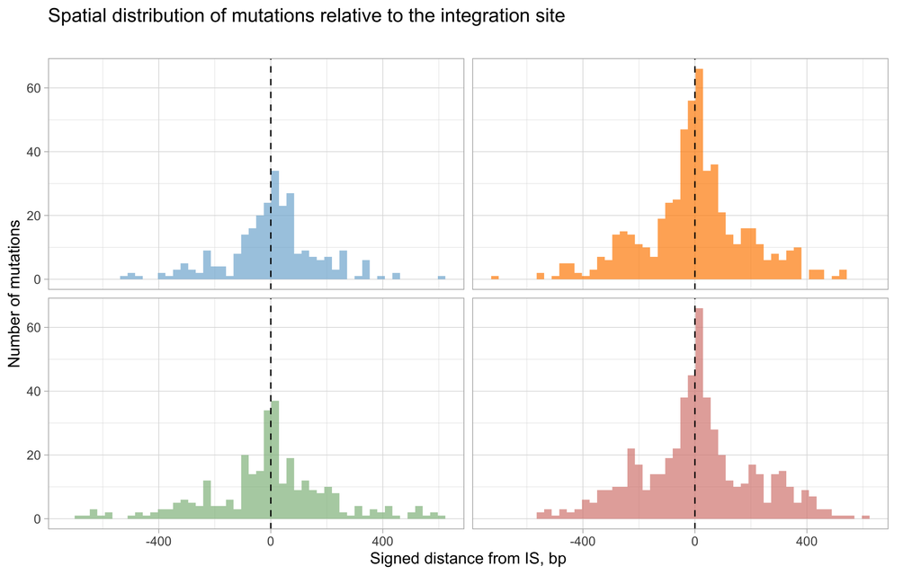

```r
p_distance_hist <- ggplot(
  df_distance,
  aes(x = distance_from_is, fill = GenVec)
) +
  geom_histogram(
    bins = 50,
    alpha = 0.7,
    position = "identity"
  ) +
  geom_vline(
    xintercept = 0,
    linetype = "dashed",
    linewidth = 0.4
  ) +
  facet_grid(Genotype ~ Vector) +
  scale_fill_manual(values = dataset_colors, drop = FALSE) +
  my_theme +
  labs(
    title = "Spatial distribution of mutations relative to the integration site",
    x = "Signed distance from IS, bp",
    y = "Number of mutations"
  ) +
  theme(
    legend.position = "none",
    strip.background = element_blank()
  )

p_distance_hist
```

```r
ggsave(
  filename = file.path(plot_dir, "distance_from_is_histogram.png"),
  plot = p_distance_hist,
  width = 8,
  height = 5,
  dpi = 300
)

ggsave(
  filename = file.path(plot_dir, "distance_from_is_histogram.pdf"),
  plot = p_distance_hist,
  width = 8,
  height = 5
)
```

## 6.7 Plot: absolute distance from integration site

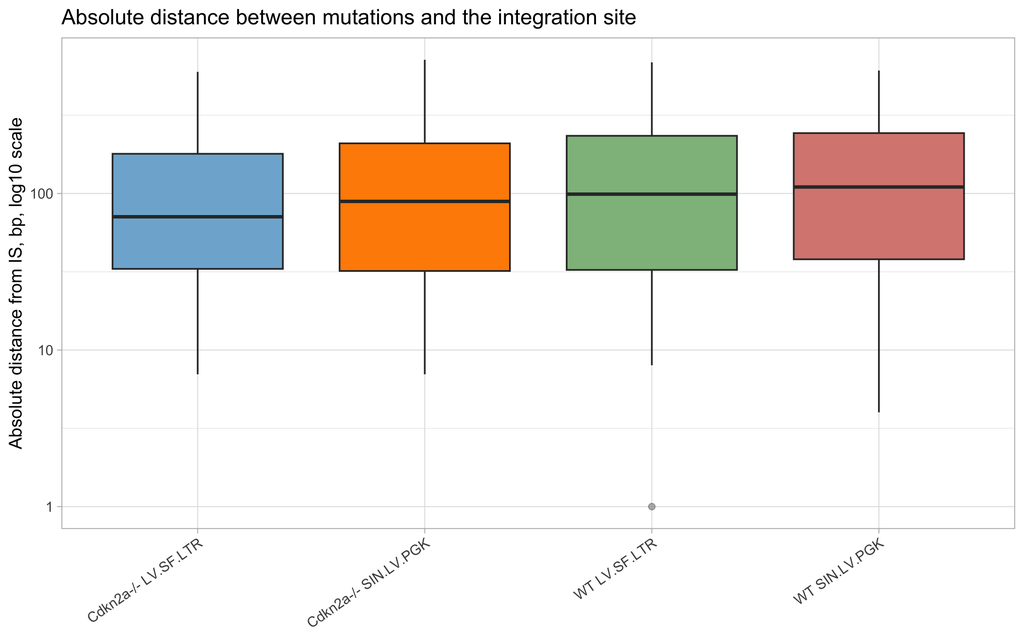

```r
p_abs_distance_boxplot <- ggplot(
  df_distance,
  aes(x = GenVec, y = abs_distance_from_is, fill = GenVec)
) +
  geom_boxplot(outlier.alpha = 0.35) +
  scale_y_log10() +
  scale_fill_manual(values = dataset_colors, drop = FALSE) +
  my_theme +
  labs(
    title = "Absolute distance between mutations and the integration site",
    x = NULL,
    y = "Absolute distance from IS, bp, log10 scale"
  ) +
  theme(
    legend.position = "none",
    axis.text.x = element_text(angle = 35, hjust = 1)
  )

p_abs_distance_boxplot
```

```r
ggsave(
  filename = file.path(plot_dir, "absolute_distance_from_is_boxplot.png"),
  plot = p_abs_distance_boxplot,
  width = 8,
  height = 5,
  dpi = 300
)

ggsave(
  filename = file.path(plot_dir, "absolute_distance_from_is_boxplot.pdf"),
  plot = p_abs_distance_boxplot,
  width = 8,
  height = 5
)
```

# 7 2. Read-end and Phred-quality checks

## 7.1 Rationale

This analysis evaluates whether ALT-supporting bases show evidence of technical bias compared with REF-supporting bases.

The two main variables are:

- `delta_ALT_minus_REF_dist_to_end`
- `delta_ALT_minus_REF_phred`

Interpretation:

- `delta_ALT_minus_REF_dist_to_end < 0`: ALT-supporting bases are closer to the nearest read end than REF-supporting bases.
- `delta_ALT_minus_REF_dist_to_end > 0`: ALT-supporting bases are farther from the nearest read end than REF-supporting bases.
- `delta_ALT_minus_REF_phred < 0`: ALT-supporting bases have lower mean Phred quality than REF-supporting bases.
- `delta_ALT_minus_REF_phred > 0`: ALT-supporting bases have higher mean Phred quality than REF-supporting bases.

## 7.2 Build quality table

```r
df_quality <- df_phred %>%
  mutate(
    delta_ALT_minus_REF_dist_to_end =
      as.numeric(delta_ALT_minus_REF_dist_to_end),
    delta_ALT_minus_REF_phred =
      as.numeric(delta_ALT_minus_REF_phred)
  ) %>%
  filter(
    !is.na(delta_ALT_minus_REF_dist_to_end),
    !is.na(delta_ALT_minus_REF_phred)
  )

if ("GenVec" %in% names(df_quality)) {
  df_quality <- df_quality %>%
    mutate(GenVec = factor(GenVec, levels = dataset_levels))
}

if (nrow(df_quality) == 0) {
  stop("No valid rows available after building df_quality.")
}

head(df_quality, 10) %>%
  kable(caption = "First rows of the quality table")
```

First rows of the quality table

| GenVec | PoolID | ID_gene | mutation_id | n_reads_REF | n_reads_ALT | mean_phred_REF | mean_phred_ALT | mean_dist_to_end_REF | mean_dist_to_end_ALT | delta_ALT_minus_REF_phred | delta_ALT_minus_REF_dist_to_end |
| --- | --- | --- | --- | --- | --- | --- | --- | --- | --- | --- | --- |
| NA | E2P1123 | 5033428I22Rik_+__chr8_59879464_-_ | 5033428I22Rik_+__chr8_59879464_-_\|chr8_59879373_A_G | 6 | 8 | 38.83333 | 33.87500 | 0.1872076 | 0.2216978 | -4.9583333 | 0.0344902 |
| NA | E2P1123 | AU022793_+__chr15_39810777_+_ | AU022793_+__chr15_39810777_+_\|chr15_39810814_A_G | 343 | 10 | 37.45190 | 34.60000 | 0.2921880 | 0.1810226 | -2.8518950 | -0.1111654 |
| NA | E2P1123 | Ash1l_+__chr3_88767012_+_ | Ash1l_+__chr3_88767012_+_\|chr3_88767057_G_A | 35 | 14 | 38.11429 | 38.57143 | 0.3745926 | 0.3609937 | 0.4571429 | -0.0135989 |
| NA | E2P1123 | Camk1d_-__chr2_5348737_+_ | Camk1d_-__chr2_5348737_+_\|chr2_5348774_C_T | 165 | 10 | 36.65455 | 33.90000 | 0.3470836 | 0.2453293 | -2.7545455 | -0.1017543 |
| NA | E2P1123 | Ctso_+__chr3_81565179_+_ | Ctso_+__chr3_81565179_+_\|chr3_81565230_C_T | 281 | 13 | 37.56940 | 34.76923 | 0.3381937 | 0.3490638 | -2.8001642 | 0.0108700 |
| NA | E2P1123 | Dmtf1_-__chr5_9154562_+_ | Dmtf1_-__chr5_9154562_+_\|chr5_9154575_T_C | 501 | 17 | 37.03992 | 34.47059 | 0.1649347 | 0.1375074 | -2.5693319 | -0.0274274 |
| NA | E2P1123 | E130308A19Rik_+__chr4_59707968_+_ | E130308A19Rik_+__chr4_59707968_+_\|chr4_59708039_A_G | 315 | 9 | 37.40000 | 38.11111 | 0.3438995 | 0.3440915 | 0.7111111 | 0.0001921 |
| NA | E2P1123 | Gca_+__chr2_62525161_-_ | Gca_+__chr2_62525161_-_\|chr2_62525134_G_A | 786 | 18 | 38.30916 | 38.83333 | 0.2882822 | 0.2416298 | 0.5241730 | -0.0466523 |
| NA | E2P1123 | Gja1_+__chr10_56276257_-_ | Gja1_+__chr10_56276257_-_\|chr10_56276231_C_T | 410 | 11 | 37.13171 | 37.36364 | 0.2598375 | 0.2725232 | 0.2319290 | 0.0126857 |
| NA | E2P1123 | Gm20594_+__chr6_79755933_+_ | Gm20594_+__chr6_79755933_+_\|chr6_79755998_T_C | 50 | 16 | 36.38000 | 36.62500 | 0.3405929 | 0.3217793 | 0.2450000 | -0.0188136 |

## 7.3 Descriptive summary

```r
quality_summary <- df_quality %>%
  summarise(
    n_snp_mutations = n(),

    mean_delta_read_end_distance =
      mean(delta_ALT_minus_REF_dist_to_end, na.rm = TRUE),

    median_delta_read_end_distance =
      median(delta_ALT_minus_REF_dist_to_end, na.rm = TRUE),

    iqr_delta_read_end_distance =
      IQR(delta_ALT_minus_REF_dist_to_end, na.rm = TRUE),

    pct_alt_closer_to_read_end =
      mean(delta_ALT_minus_REF_dist_to_end < 0, na.rm = TRUE) * 100,

    mean_delta_phred =
      mean(delta_ALT_minus_REF_phred, na.rm = TRUE),

    median_delta_phred =
      median(delta_ALT_minus_REF_phred, na.rm = TRUE),

    iqr_delta_phred =
      IQR(delta_ALT_minus_REF_phred, na.rm = TRUE),

    pct_alt_lower_phred =
      mean(delta_ALT_minus_REF_phred < 0, na.rm = TRUE) * 100
  )

write.csv(
  quality_summary,
  file.path(table_dir, "quality_delta_summary.csv"),
  row.names = FALSE
)

quality_summary %>%
  kable(
    digits = 4,
    caption = "Global ALT-minus-REF read-end and Phred-quality summaries"
  )
```

Global ALT-minus-REF read-end and Phred-quality summaries

| n_snp_mutations | mean_delta_read_end_distance | median_delta_read_end_distance | iqr_delta_read_end_distance | pct_alt_closer_to_read_end | mean_delta_phred | median_delta_phred | iqr_delta_phred | pct_alt_lower_phred |
| --- | --- | --- | --- | --- | --- | --- | --- | --- |
| 1639 | 2e-04 | 0.002 | 0.0949 | 48.1391 | -2.1064 | -0.4801 | 2.9178 | 62.3551 |

## 7.4 Optional summary by dataset

This section is generated only if `GenVec` is present in `df_phred_wide.xlsx`.

```r
if ("GenVec" %in% names(df_quality) && any(!is.na(df_quality$GenVec))) {

  quality_summary_by_dataset <- df_quality %>%
    filter(!is.na(GenVec)) %>%
    group_by(GenVec) %>%
    summarise(
      n_snp_mutations = n(),

      median_delta_read_end_distance =
        median(delta_ALT_minus_REF_dist_to_end, na.rm = TRUE),

      pct_alt_closer_to_read_end =
        mean(delta_ALT_minus_REF_dist_to_end < 0, na.rm = TRUE) * 100,

      median_delta_phred =
        median(delta_ALT_minus_REF_phred, na.rm = TRUE),

      pct_alt_lower_phred =
        mean(delta_ALT_minus_REF_phred < 0, na.rm = TRUE) * 100,

      .groups = "drop"
    )

  write.csv(
    quality_summary_by_dataset,
    file.path(table_dir, "quality_delta_summary_by_dataset.csv"),
    row.names = FALSE
  )

  quality_summary_by_dataset %>%
    kable(
      digits = 4,
      caption = "ALT-minus-REF read-end and Phred-quality summaries by dataset"
    )
}
```

## 7.5 Statistical tests on quality deltas

A one-sample Wilcoxon signed-rank test is used to evaluate whether each ALT-minus-REF delta distribution is centered around zero.

```r
read_end_wilcox <- safe_wilcox_test(
  df_quality$delta_ALT_minus_REF_dist_to_end
) %>%
  mutate(variable = "delta_ALT_minus_REF_dist_to_end", .before = 1)

phred_wilcox <- safe_wilcox_test(
  df_quality$delta_ALT_minus_REF_phred
) %>%
  mutate(variable = "delta_ALT_minus_REF_phred", .before = 1)

quality_wilcox_results <- bind_rows(
  read_end_wilcox,
  phred_wilcox
)

write.csv(
  quality_wilcox_results,
  file.path(table_dir, "quality_delta_wilcox_tests.csv"),
  row.names = FALSE
)

quality_wilcox_results %>%
  kable(
    digits = 4,
    caption = "Wilcoxon signed-rank tests on ALT-minus-REF quality deltas"
  )
```

Wilcoxon signed-rank tests on ALT-minus-REF quality deltas

| variable | statistic | p.value | method | alternative | note |
| --- | --- | --- | --- | --- | --- |
| delta_ALT_minus_REF_dist_to_end | 684995.5 | 0.4185 | Wilcoxon signed rank test with continuity correction | two.sided | NA |
| delta_ALT_minus_REF_phred | 380587.0 | 0.0000 | Wilcoxon signed rank test with continuity correction | two.sided | NA |

## 7.6 Plot: ALT-minus-REF distance from nearest read end

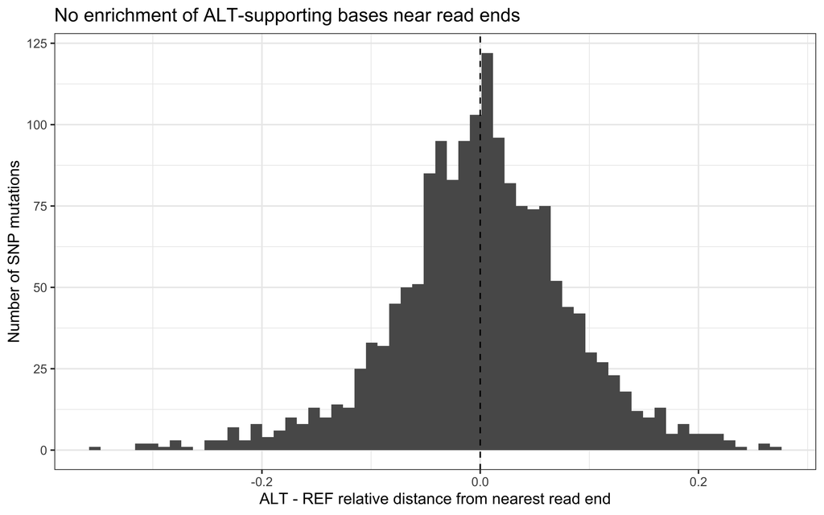

```r
p_read_end <- ggplot(
  df_quality,
  aes(x = delta_ALT_minus_REF_dist_to_end)
) +
  geom_histogram(bins = 60) +
  geom_vline(xintercept = 0, linetype = "dashed") +
  theme_bw() +
  labs(
    x = "ALT - REF relative distance from nearest read end",
    y = "Number of SNP mutations",
    title = "No enrichment of ALT-supporting bases near read ends"
  )

p_read_end
```

```r
ggsave(
  filename = file.path(plot_dir, "alt_minus_ref_read_end_distance.png"),
  plot = p_read_end,
  width = 8,
  height = 5,
  dpi = 300
)

ggsave(
  filename = file.path(plot_dir, "alt_minus_ref_read_end_distance.pdf"),
  plot = p_read_end,
  width = 8,
  height = 5
)
```

## 7.7 Plot: ALT-minus-REF Phred quality

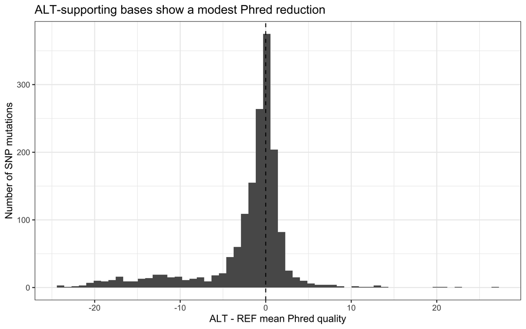

```r
p_phred <- ggplot(
  df_quality,
  aes(x = delta_ALT_minus_REF_phred)
) +
  geom_histogram(bins = 60) +
  geom_vline(xintercept = 0, linetype = "dashed") +
  theme_bw() +
  labs(
    x = "ALT - REF mean Phred quality",
    y = "Number of SNP mutations",
    title = "ALT-supporting bases show a modest Phred reduction"
  )

p_phred
```

```r
ggsave(
  filename = file.path(plot_dir, "alt_minus_ref_phred_quality.png"),
  plot = p_phred,
  width = 8,
  height = 5,
  dpi = 300
)

ggsave(
  filename = file.path(plot_dir, "alt_minus_ref_phred_quality.pdf"),
  plot = p_phred,
  width = 8,
  height = 5
)
```

# 8 3. Optional stratified quality plots

These plots are generated only if the `GenVec` column is available in `df_phred_wide.xlsx`.

```r
if ("GenVec" %in% names(df_quality) && any(!is.na(df_quality$GenVec))) {

  p_read_end_by_dataset <- ggplot(
    df_quality,
    aes(x = delta_ALT_minus_REF_dist_to_end, fill = GenVec)
  ) +
    geom_histogram(
      bins = 60,
      alpha = 0.7,
      position = "identity"
    ) +
    geom_vline(xintercept = 0, linetype = "dashed") +
    facet_wrap(~ GenVec, scales = "free_y") +
    scale_fill_manual(values = dataset_colors, drop = FALSE) +
    theme_bw() +
    labs(
      x = "ALT - REF relative distance from nearest read end",
      y = "Number of SNP mutations",
      title = "Read-end distance delta by dataset"
    ) +
    theme(legend.position = "none")

  p_read_end_by_dataset

  ggsave(
    filename = file.path(plot_dir, "alt_minus_ref_read_end_distance_by_dataset.png"),
    plot = p_read_end_by_dataset,
    width = 9,
    height = 6,
    dpi = 300
  )

  p_phred_by_dataset <- ggplot(
    df_quality,
    aes(x = delta_ALT_minus_REF_phred, fill = GenVec)
  ) +
    geom_histogram(
      bins = 60,
      alpha = 0.7,
      position = "identity"
    ) +
    geom_vline(xintercept = 0, linetype = "dashed") +
    facet_wrap(~ GenVec, scales = "free_y") +
    scale_fill_manual(values = dataset_colors, drop = FALSE) +
    theme_bw() +
    labs(
      x = "ALT - REF mean Phred quality",
      y = "Number of SNP mutations",
      title = "Phred-quality delta by dataset"
    ) +
    theme(legend.position = "none")

  p_phred_by_dataset

  ggsave(
    filename = file.path(plot_dir, "alt_minus_ref_phred_quality_by_dataset.png"),
    plot = p_phred_by_dataset,
    width = 9,
    height = 6,
    dpi = 300
  )
}
```

# 9 4. Output files

The report also saves the main output tables and plots to disk.

```r
list.files(output_dir, recursive = TRUE) %>%
  data.frame(file = .) %>%
  kable(caption = "Files generated by this report")
```

Files generated by this report

| file |
| --- |
| plots/absolute_distance_from_is_boxplot.pdf |
| plots/absolute_distance_from_is_boxplot.png |
| plots/alt_minus_ref_phred_quality.pdf |
| plots/alt_minus_ref_phred_quality.png |
| plots/alt_minus_ref_read_end_distance.pdf |
| plots/alt_minus_ref_read_end_distance.png |
| plots/distance_from_is_histogram.pdf |
| plots/distance_from_is_histogram.png |
| tables/absolute_distance_from_is_kruskal_test.csv |
| tables/distance_from_is_summary.csv |
| tables/distance_from_is_wilcox_tests.csv |
| tables/quality_delta_summary.csv |
| tables/quality_delta_wilcox_tests.csv |